# R for Register Data Users

We can change the axis labels and add a title:

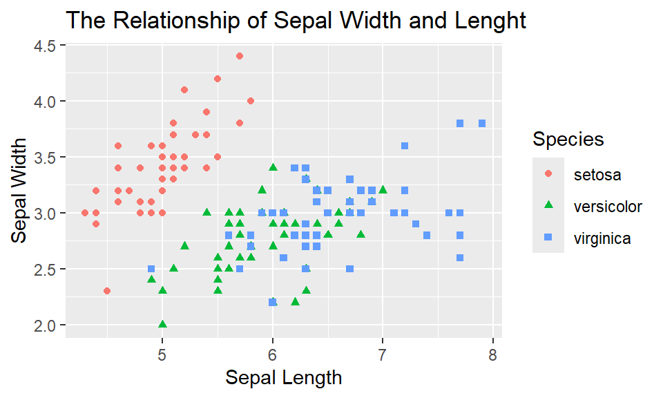

```r
plot +
  labs(x='Sepal Length',
       y='Sepal Width',
       title='The Relationship of Sepal Width and Lenght')
```

We could also add a regression line:

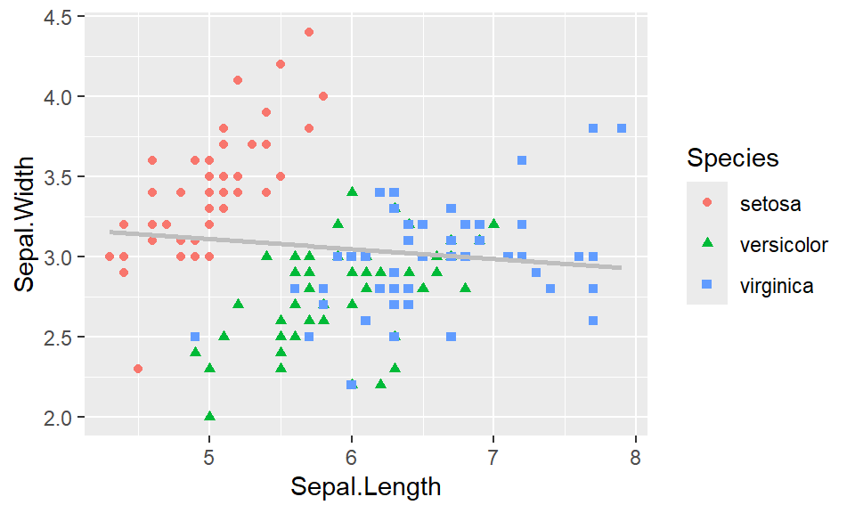

```r
plot +
  geom_smooth(method = 'lm', se = F,color='gray')
```

Maybe it would be better to have each species in a separate graph:

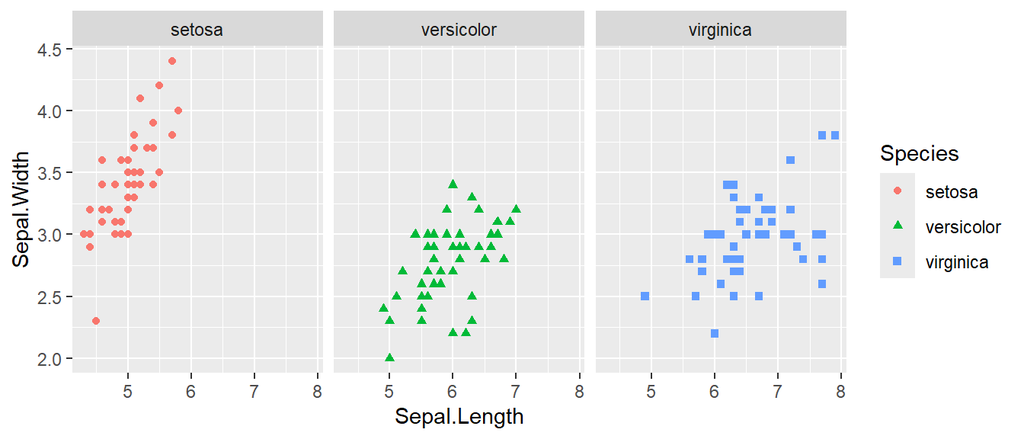

```r
plot +
  facet_wrap(~Species)
```

`facet_grid` allows to specify which variables should be used in the rows and which in the columns.

We are not confined to points. Here is a histogram of sepal length.

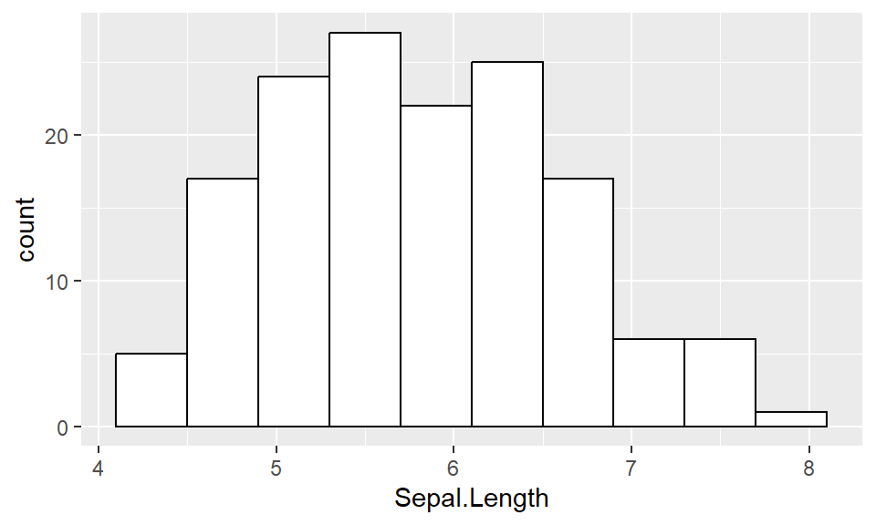

```r
ggplot(iris) +
  geom_histogram(mapping=aes(x=Sepal.Length),
                 bins = 10,color='black',fill='white')
```

There are many different geometries you can use:

- Lines: `geom_line`
- Boxplots: `geom_boxplot`
- Densities: `geom_density`
- Maps: `geom_map`
- Error Bars: `geom_errorbar`
- Uncertainty Intervals: `geom_ribbon`

and many more.

You can customize almost every aspect of a plot: axes, labels, grid lines, legend, orientation, size, palettes. However, `ggplot2` also offers a set of themes that modify several aspects of a figure at once:

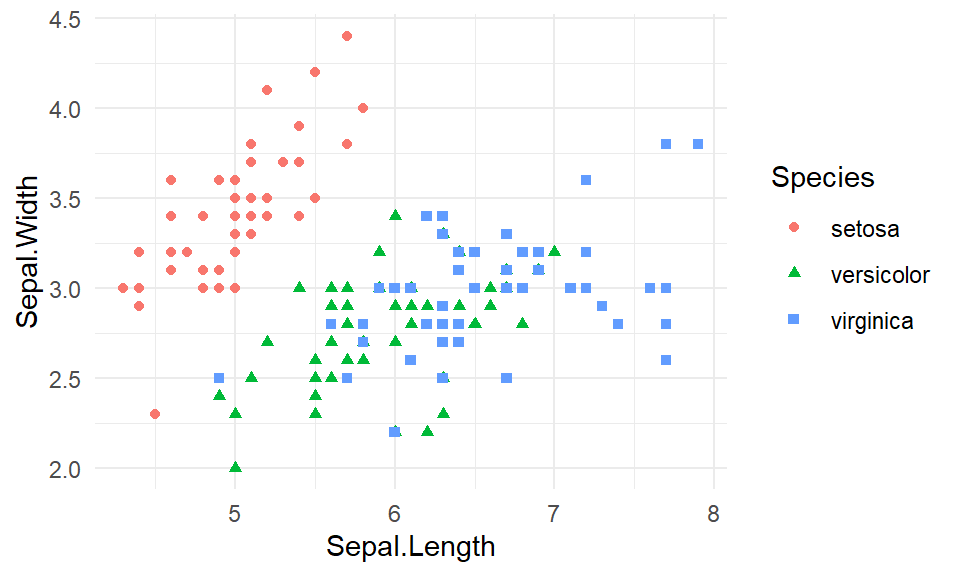

```r
plot +
  theme_minimal()
```

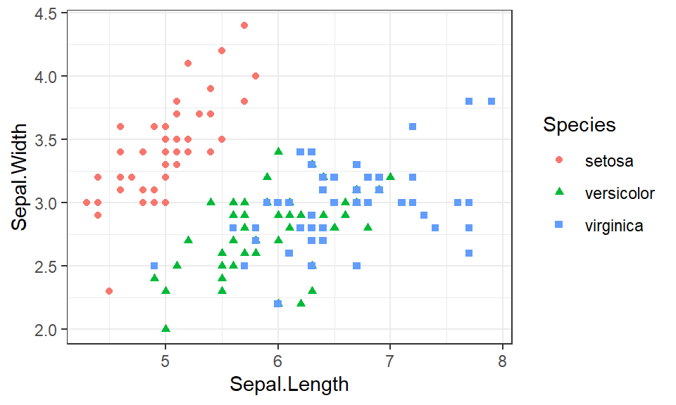

```r
plot +
  theme_bw()
```

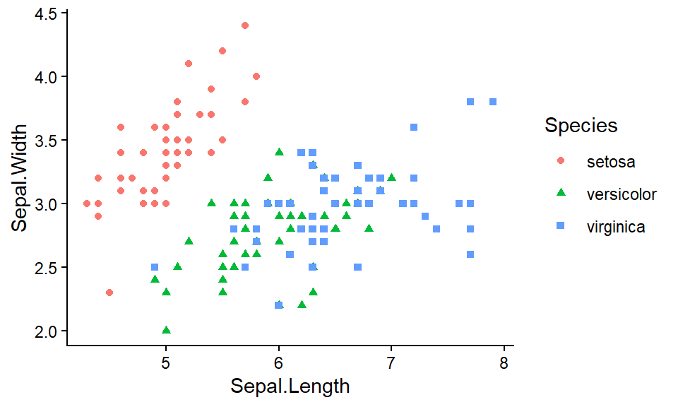

```r
plot +
  theme_classic()
```

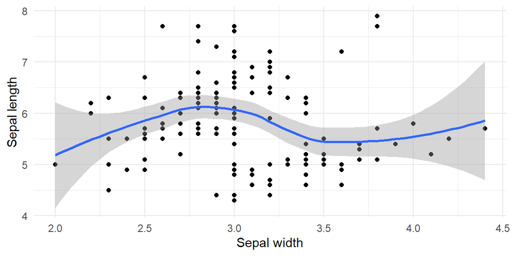

```r
# Create plot of sepal length over width
plot1 <- iris |>
  ggplot() +
  geom_point(mapping=aes(x=Sepal.Width,y=Sepal.Length)) +
  geom_smooth(mapping=aes(x=Sepal.Width,y=Sepal.Length)) +
  labs(x='Sepal width',y='Sepal length') +
  theme_minimal()

plot1
```

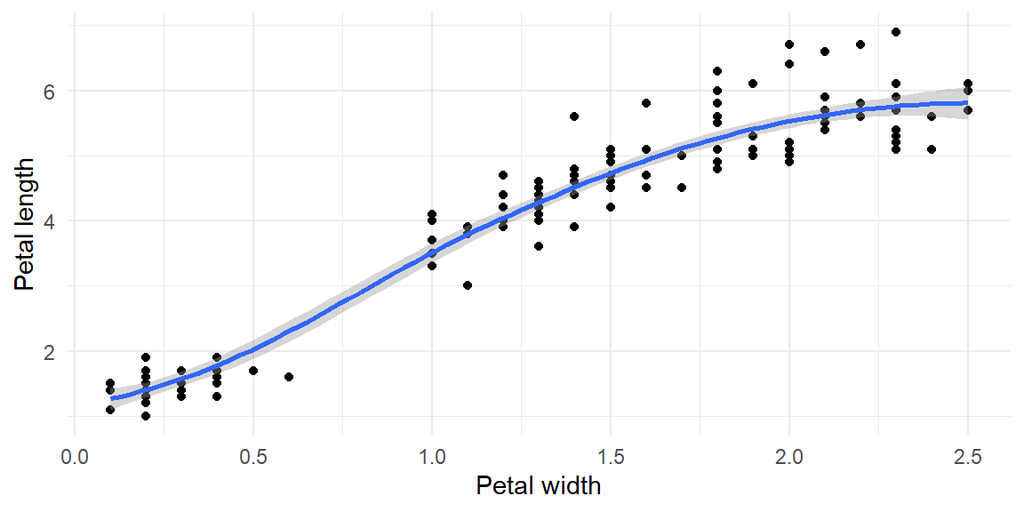

```r
# Create plot of petal length over width
plot2 <- iris |>
  ggplot() +
  geom_point(mapping=aes(x=Petal.Width,y=Petal.Length)) +
  geom_smooth(mapping=aes(x=Petal.Width,y=Petal.Length)) +
  labs(x='Petal width',y='Petal length') +
  theme_minimal()

plot2
```

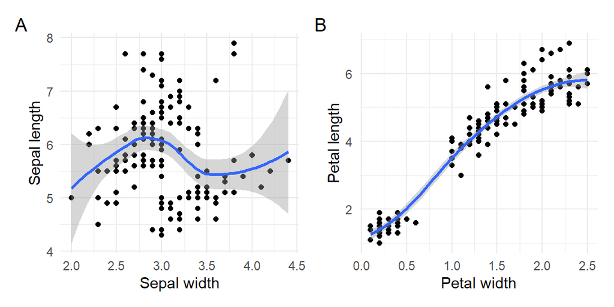

```r
# Combine
library(patchwork)
plot1 + plot2 + plot_annotation(tag_levels = 'A')
```

We can save plots through `R`’s graphic devices. I am a fan of svg, but there are many formats. The basic syntax is:

```r
svg(here('figures','my_first_plot.svg'),width = 6,height = 4)
plot1 + plot2 + plot_annotation(tag_levels = 'A')
dev.off()
```

I would not recommend non-vector formats (e.g. png or jpeg), because it’s hard to get them in the desired definition (at least I find it hard).

*Exercise*

Using the `iris` dataset, create a new graph with a different box plot of `Sepal.Width` for each Species. Label the axes in an appropriate way. Use the theme you prefer.

```r
ggplot(data=iris) +
  geom_*(mapping=aes(x=,y=)) +
  labs() +
  theme_*()
```

*Solution*

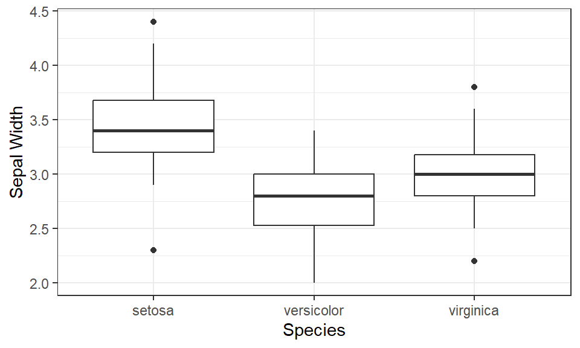

```r
ggplot(data=iris) +
  geom_boxplot(mapping=aes(x=Species,y=Sepal.Width)) +
  labs(y='Sepal Width') +
  theme_bw()
```

There are more packages for specialized graphs. Some examples:

- `ggh4x` extensions to `ggplot`, particularly useful for fancy faceting
- `geofacet` geofaceting
- `colorspace` colors
- `ggsci` those beautiful color palettes from big journals

### Amazing Tables with `gt`

R is great for automating table creation. We can use our frequency table in `freq_table_wide` to illustrate what we can do.

```r
library(gt)

# Fix column order
setcolorder(
  freq_table_wide,
  c('age_group','every day smoker','some day smoker',
    'former smoker','never smoker','NA')
  )

# We can make the proportions into percentage so they look prettier
vars_to_multiply <- c(
  'every day smoker','some day smoker',
  'former smoker','never smoker','NA'
  )

freq_table_wide[,(vars_to_multiply):=lapply(.SD,function(x) x*100),.SDcols = vars_to_multiply]

freq_table_wide |>
  gt() |>
  cols_label(
    age_group='Age',
    `every day smoker`='Every day smoker',
    `some day smoker`='Some day smoker',
    `former smoker`='Former smoker',
    `never smoker`='Never smoker',
    `NA`='Missing'
  ) |>
  fmt_number(
    `every day smoker`:`NA`,
    decimals = 2
  )
```

| Age | Every day smoker | Some day smoker | Former smoker | Never smoker | Missing |
| --- | --- | --- | --- | --- | --- |
| [0,5) | 0.00 | 0.00 | 0.00 | 0.00 | 100.00 |
| [5,10) | 0.00 | 0.00 | 0.00 | 0.00 | 100.00 |
| [10,15) | 0.00 | 0.00 | 0.00 | 0.00 | 100.00 |
| [15,20) | 1.16 | 0.56 | 0.21 | 8.05 | 90.02 |
| [20,25) | 5.02 | 2.18 | 2.79 | 25.42 | 64.59 |
| [25,30) | 6.99 | 2.60 | 4.33 | 26.27 | 59.83 |
| [30,35) | 6.39 | 2.18 | 5.96 | 26.65 | 58.83 |
| [35,40) | 6.19 | 1.95 | 5.58 | 26.14 | 60.14 |
| [40,45) | 5.76 | 1.82 | 5.82 | 24.55 | 62.05 |
| [45,50) | 6.96 | 1.84 | 6.95 | 22.45 | 61.80 |
| [50,55) | 8.05 | 1.76 | 9.15 | 19.55 | 61.49 |
| [55,60) | 7.21 | 1.69 | 10.78 | 21.62 | 58.70 |
| [60,65) | 6.63 | 1.55 | 14.08 | 21.96 | 55.78 |
| [65,70) | 5.95 | 0.95 | 17.64 | 23.05 | 52.41 |
| [70,75) | 5.07 | 1.06 | 19.05 | 25.51 | 49.30 |
| [75,80) | 3.07 | 0.77 | 21.79 | 26.60 | 47.77 |
| [80,85) | 2.26 | 0.71 | 20.13 | 33.62 | 43.29 |
| 85+ | 0.64 | 0.48 | 18.09 | 39.55 | 41.24 |

Now another example with our predictions in `y_summary`, to show some additional functionalities.

```r
# Drop median and observed proportion and give better names
y_summary[,c('y_real.prop','y_median'):=NULL]
setnames(y_summary,c('y_real.sex','y_real.edu'),c('sex','edu'))

# I don't like typing so simplify sex
y_summary[,sex:=fifelse(sex=='female','f','m')]

# We can make the proportions into percentage so they look prettier
vars_to_multiply <- c('y_mean','y_025','y_975')

y_summary[,(vars_to_multiply):=lapply(.SD,function(x) x*100),.SDcols = vars_to_multiply]

# First reshape to wide
y_summary_table <- dcast(
  y_summary,
  edu ~ sex,
  value.var = c('y_mean','y_025','y_975')
)

# Set column order
setcolorder(y_summary_table,c('edu','y_mean_f','y_025_f','y_975_f'))

# Create table
y_summary_table |>
  gt() |>
  cols_label(
    edu='Educational attainment',
    y_mean_f='Mean',
    y_025_f='2.5th pct',
    y_975_f='97.5th pct',
    y_mean_m='Mean',
    y_025_m='2.5th pct',
    y_975_m='97.5th pct'
  ) |>
  fmt_number(
    y_mean_f:y_975_m,
    decimals = 2
  ) |>
  tab_spanner(
    y_mean_f:y_975_f,
    label='Female'
  ) |>
  tab_spanner(
    y_mean_m:y_975_m,
    label='Male'
  )
```

| Educational attainment | Female Mean | Female 2.5th pct | Female 97.5th pct | Male Mean | Male 2.5th pct | Male 97.5th pct |
| --- | --- | --- | --- | --- | --- | --- |
| less than high school | 10.61 | 9.82 | 11.37 | 8.26 | 7.45 | 9.08 |
| high school | 10.21 | 9.56 | 10.87 | 9.21 | 8.56 | 9.88 |
| some college | 8.31 | 7.74 | 8.92 | 9.57 | 8.88 | 10.28 |
| bachelor | 3.97 | 3.08 | 4.84 | 3.57 | 2.73 | 4.38 |
| graduate | 2.34 | 1.30 | 3.46 | 2.95 | 1.96 | 4.00 |

We could have made something simpler by first creating a pretty formatted column

```r
# Create summary column and remove the rest
# Create utility function to round and pad
# (Yes this might have gotten a bit out of hand)
round_and_pad <- function(x,decimals=2) {
  rounded_x <- as.character(round(x,decimals))

  # Split integer and decimal part
  integer_part <- str_match(rounded_x,'^\\d+') # Regular expressions!

  # Is there a decimal part?
  decimal_part <- fifelse(
    str_detect(rounded_x,'\\.'),
    str_match(rounded_x,'\\d+$'),
    paste0(rep('0',decimals),collapse='')
    )
  # Is this a vectorized if else statement? Yes it is!

  # Pad integer part
  integer_part <- str_pad(integer_part,width = 2, pad=' ',side='left')

  # Pad decimal part
  decimal_part <- str_pad(decimal_part,width = 2, pad='0',side='right')

  clean_x <- paste0(integer_part,'.',decimal_part)
  clean_x
}

y_summary[,y_sum:=paste0(
  round_and_pad(y_mean,2),
  ' (',
  round_and_pad(y_025,2),
  ', ',
  round_and_pad(y_975,2),
  ')'
  )]

# First reshape to wide
y_summary_table <- dcast(
  y_summary,
  edu ~ sex,
  value.var = c('y_sum')
)

# Create table
y_summary_table |>
  gt() |>
  cols_label(
    edu='Educational attainment',
    f='Female',
    m='Male'
  ) |>
  tab_spanner(
    f:m,
    label='Mean (2.5 pct, 97.5 pct)'
  )
```

| Educational attainment | Mean (2.5 pct, 97.5 pct) Female | Mean (2.5 pct, 97.5 pct) Male |
| --- | --- | --- |
| less than high school | 10.61 ( 9.82, 11.37) | 8.26 ( 7.45, 9.08) |
| high school | 10.21 ( 9.56, 10.87) | 9.21 ( 8.56, 9.88) |
| some college | 8.31 ( 7.74, 8.92) | 9.57 ( 8.88, 10.28) |
| bachelor | 3.97 ( 3.08, 4.84) | 3.57 ( 2.73, 4.38) |
| graduate | 2.34 ( 1.30, 3.46) | 2.95 ( 1.96, 4.00) |

To save, we can do

```r
# Create table
y_summary_table |>
  gt() |>
  cols_label(
    edu='Educational attainment',
    f='Female',
    m='Male'
  ) |>
  tab_spanner(
    f:m,
    label='Mean (2.5 pct, 97.5 pct)'
  ) |>
  gtsave(filename = here('tables','my_table.docx'))
```

### Ask Me Anything

We covered quite a bit of material, and you should be able to do most data cleaning, model fitting, and post-estimation operations starting from the basic building blocks we saw. But, you might have specific applications in mind that you are not quite sure how to implement with the tools we saw. This is a good moment to ask.